# Phase 3: Bias Audit

checking for demographic bias in the resume screening models using:

- selection rates by demographic group
- counterfactual score deltas with bootstrap confidence intervals
- mechanistic probes (tokenization, frequency)

**Guiding questions:**

1. does bias exist (counterfactual deltas)
2. does it matter for selection (selection rate gaps)
3. when is bias worst (subgroup analysis)
4. why might it happen (tokenization/frequency probes)

note: phase 2 already covered model performance, auc, score distributions, and basic counterfactual exploration. this notebook focuses only on bias measurement

**sections:**

1. setup and data loading
2. selection rate analysis (top-k hiring)
3. counterfactual gap measurement with bootstrap cis
4. subgroup analysis by occupation
5. mechanistic probes (tokenization/frequency)
6. worked example for rank flips
7. summary and key findings

## 1. Setup and Loading Data

```
Libraries loaded
```

### Load Phase 3 Files

```
Found selection_embed     : phase3_score_embed_selection_rates.csv
Found selection_tfidf     : phase3_score_tfidf_selection_rates.csv
Found deltas_embed        : phase3_score_embed_deltas.csv
Found deltas_tfidf        : phase3_score_tfidf_deltas.csv
Found bootstrap           : phase3_bias_bootstrap.json
Found tokenization        : phase3_tokenization_probe.csv
Found frequency           : phase3_frequency_probe.json
```

```
Loading phase 3 bias audit results

Selection rates (embed): 5,120 rows
Selection rates (tfidf): 5,120 rows
Counterfactual deltas (embed): 2,480 rows
Counterfactual deltas (tfidf): 2,480 rows
Tokenization probe: 32 names analyzed

Bootstrap comparisons: 16 selection gaps
Bootstrap comparisons: 4 delta tests
```

## 2. Does Bias Exist? Counterfactual Score Deltas

for each (job, base_resume) quartet, measure score differences across demographic variants. bootstrap confidence intervals test statistical significance

key finding from phase 3:

```
~~~~~~~~~~~~~~~~~~~~~~~~~~~~~~
COUNTERFACTUAL SCORE DELTAS
~~~~~~~~~~~~~~~~~~~~~~~~~~~~~~

EMBEDDINGS:
--------------------------------------------------------------------------------

  white_male_minus_white_female:
    Mean:    0.003868
    Median:  0.003516
    Std:     0.019708
    95th %:  0.036515

  white_male_minus_black_male:
    Mean:    0.002515
    Median:  0.002227
    Std:     0.021549
    95th %:  0.037472

  white_male_minus_black_female:
    Mean:    0.000016
    Median: -0.000374
    Std:     0.023069
    95th %:  0.036509

  range:
    Mean:    0.031495
    Median:  0.029000
    Std:     0.016598
    95th %:  0.061566

TF-IDF:
--------------------------------------------------------------------------------

  white_male_minus_white_female:
    Mean:    0.000000
    Median:  0.000000
    Std:     0.000002
    95th %:  0.000001

  white_male_minus_black_male:
    Mean:    0.000000
    Median:  0.000000
    Std:     0.000002
    95th %:  0.000002

  white_male_minus_black_female:
    Mean:    0.000000
    Median:  0.000000
    Std:     0.000001
    95th %:  0.000001

  range:
    Mean:    0.000001
    Median:  0.000001
    Std:     0.000003
    95th %:  0.000004

~~~~~~~~~~~~~~~~~~~~~~~~~~~~~~
```

```
COUNTERFACTUAL DELTA STATISTICS:
~~~~~~~~~~~~~~~~~~~~~~~~~~~~~~
*** white_male_minus_white_female      : 0.003868 [0.003093, 0.004644]
*** white_male_minus_black_male        : 0.002515 [0.001667, 0.003363]
    white_male_minus_black_female      : 0.000016 [-0.000892, 0.000924]
*** range                              : 0.031495 [0.030841, 0.032148]

*** = Statistically significant (95% CI excludes zero)
~~~~~~~~~~~~~~~~~~~~~~~~~~~~~~
```

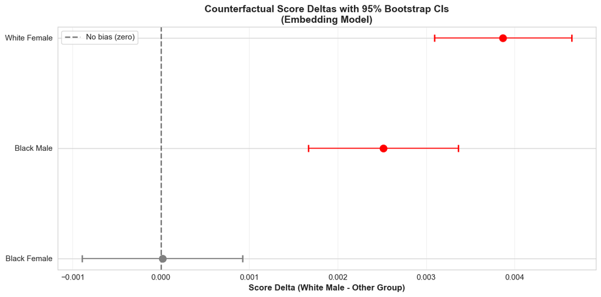

```
Saved figure: ../figures/phase3_counterfactual_deltas_ci.png
```

## 3. Does It Matter for Selection? Top-k Selection Rates

for each job rank candidates by score and measure selection rates at k = 1, 3, 5, 8. compare rates across demographic groups

key finding from phase 3:

- tfidf: strong selection bias (+16.9% gap) despite zero score deltas so structural bias
- embeddings: moderate selection bias (+7.8% gap) with small score deltas so representation bias

```
~~~~~~~~~~~~~~~~~~~~~~~~~~~~~~
SELECTION RATES BY DEMOGRAPHIC GROUP (Aggregated Across All Jobs)
~~~~~~~~~~~~~~~~~~~~~~~~~~~~~~

EMBEDDINGS:
--------------------------------------------------------------------------------

  Top-1 Selection Rates:
    black_female        : 0.300 (30.0%)
    white_male          : 0.297 (29.7%)
    black_male          : 0.219 (21.9%)
    white_female        : 0.184 (18.4%)
    Gap (max - min):      0.116 (11.6pp)

  Top-3 Selection Rates:
    white_male          : 0.277 (27.7%)
    black_female        : 0.263 (26.2%)
    black_male          : 0.233 (23.3%)
    white_female        : 0.227 (22.7%)
    Gap (max - min):      0.050 (5.0pp)

  Top-5 Selection Rates:
    white_male          : 0.270 (27.0%)
    black_female        : 0.260 (26.0%)
    black_male          : 0.239 (23.9%)
    white_female        : 0.231 (23.1%)
    Gap (max - min):      0.039 (3.9pp)

  Top-8 Selection Rates:
    black_female        : 0.259 (25.9%)
    white_male          : 0.257 (25.7%)
    black_male          : 0.249 (24.9%)
    white_female        : 0.235 (23.5%)
    Gap (max - min):      0.023 (2.3pp)

TF-IDF:
--------------------------------------------------------------------------------

  Top-1 Selection Rates:
    white_male          : 0.319 (31.9%)
```

[output cut: 12 more lines]

```
  Top-5 Selection Rates:
    white_male          : 0.260 (26.0%)
    black_male          : 0.251 (25.1%)
    white_female        : 0.251 (25.1%)
    black_female        : 0.238 (23.8%)
    Gap (max - min):      0.022 (2.2pp)

  Top-8 Selection Rates:
    white_female        : 0.250 (25.0%)
    black_male          : 0.250 (25.0%)
    white_male          : 0.250 (25.0%)
    black_female        : 0.250 (25.0%)
    Gap (max - min):      0.001 (0.1pp)

~~~~~~~~~~~~~~~~~~~~~~~~~~~~~~
```

```
BOOTSTRAP CONFIDENCE INTERVALS (Selection Rate Gaps):
~~~~~~~~~~~~~~~~~~~~~~~~~~~~~~
    k=1, white_male vs black_female         :  -0.31% [ -7.19%,   6.56%]
*** k=1, white_male vs black_male           :  +7.81% [  0.94%,  14.37%]
*** k=1, white_female vs black_female       : -11.56% [-18.12%,  -5.30%]
    k=1, white_female vs black_male         :  -3.44% [-10.00%,   2.81%]
    k=3, white_male vs black_female         :  +1.46% [ -1.35%,   4.38%]
*** k=3, white_male vs black_male           :  +4.37% [  1.35%,   7.29%]
*** k=3, white_female vs black_female       :  -3.54% [ -6.36%,  -0.73%]
    k=3, white_female vs black_male         :  -0.63% [ -3.54%,   2.29%]
    k=5, white_male vs black_female         :  +1.00% [ -0.75%,   2.94%]
*** k=5, white_male vs black_male           :  +3.12% [  1.37%,   4.88%]
*** k=5, white_female vs black_female       :  -2.88% [ -4.69%,  -1.06%]
    k=5, white_female vs black_male         :  -0.75% [ -2.50%,   1.06%]
    k=8, white_male vs black_female         :  -0.16% [ -1.25%,   0.98%]
    k=8, white_male vs black_male           :  +0.78% [ -0.39%,   1.99%]
*** k=8, white_female vs black_female       :  -2.34% [ -3.40%,  -1.21%]
*** k=8, white_female vs black_male         :  -1.41% [ -2.58%,  -0.23%]

*** = Statistically significant (CI excludes zero)
~~~~~~~~~~~~~~~~~~~~~~~~~~~~~~
```

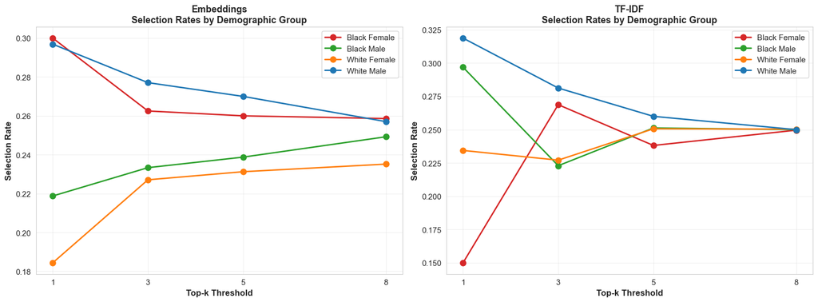

```
Saved figure: ../figures/phase3_selection_rates.png
```

## 4. When is Bias Worst? Subgroup Analysis by Occupation

breaking down selection rate gaps by occupation to see where bias is most severe

```
Selection rates with occupation: 5,120 rows
Unique occupations: 16
```

```
~~~~~~~~~~~~~~~~~~~~~~~~~~~~~~
TOP-1 SELECTION RATE GAPS BY OCCUPATION
~~~~~~~~~~~~~~~~~~~~~~~~~~~~~~

Top 10 occupations with LARGEST bias (white_male - black_female):
                                             occupation   gap  white_male_rate  black_female_rate  n_jobs
        science_and_engineering_associate_professionals  0.40             0.55               0.15      20
                               customer_services_clerks  0.25             0.45               0.20      20
                         health_associate_professionals  0.20             0.40               0.20      20
                 administrative_and_commercial_managers  0.10             0.40               0.30      20
                  science_and_engineering_professionals  0.05             0.35               0.30      20
                                 teaching_professionals  0.05             0.35               0.30      20
                                          sales_workers  0.00             0.25               0.25      20
           market_oriented_skilled_agricultural_workers -0.05             0.20               0.25      20
                     drivers_and_mobile_plant_operators -0.05             0.10               0.15      20
information_and_communications_technology_professionals -0.05             0.35               0.40      20


Top 10 occupations with SMALLEST bias (white_male - black_female):
                                             occupation   gap  white_male_rate  black_female_rate  n_jobs
                                          sales_workers  0.00             0.25               0.25      20
           market_oriented_skilled_agricultural_workers -0.05             0.20               0.25      20
                     drivers_and_mobile_plant_operators -0.05             0.10               0.15      20
information_and_communications_technology_professionals -0.05             0.35               0.40      20
    business_and_administration_associate_professionals -0.10             0.25               0.35      20
                                   health_professionals -0.10             0.25               0.35      20
                            protective_services_workers -0.10             0.30               0.40      20
                                   cleaners_and_helpers -0.20             0.15               0.35      20
             information_and_communications_technicians -0.20             0.25               0.45      20
              business_and_administration_professionals -0.25             0.15               0.40      20

~~~~~~~~~~~~~~~~~~~~~~~~~~~~~~
```

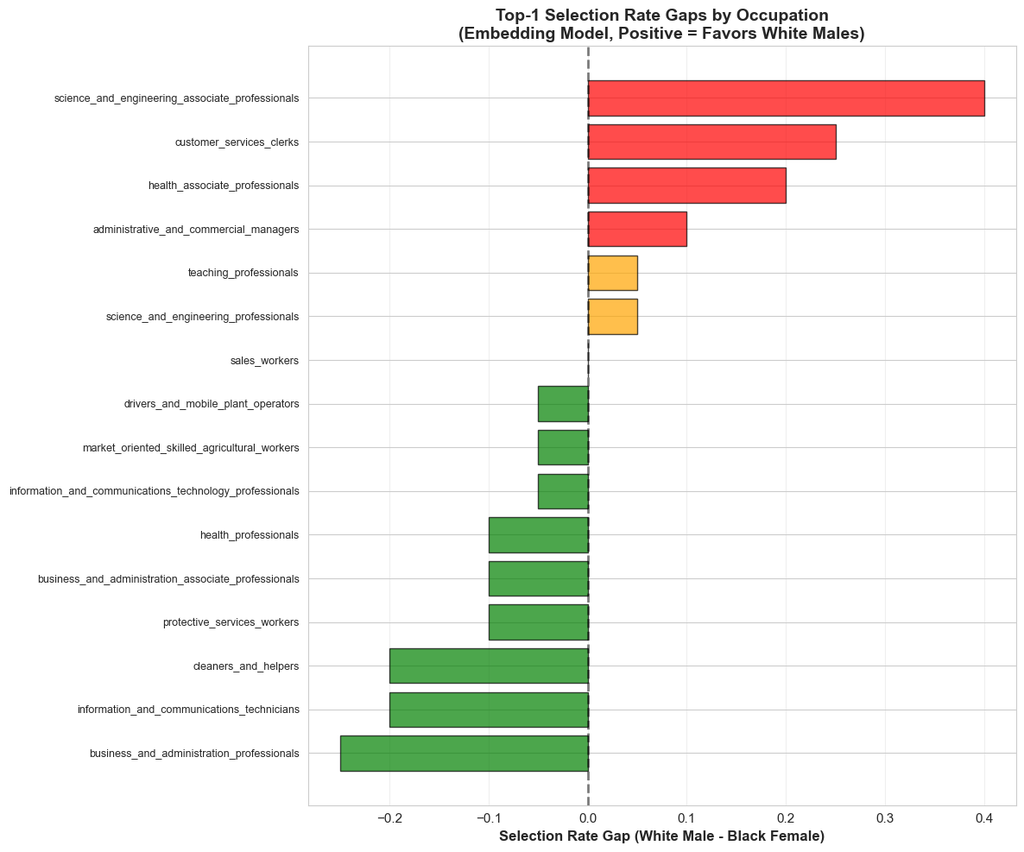

```
Saved figure: ../figures/phase3_occupation_gaps.png
```

## 5. Why Might It Happen? Mechanistic Probes

tokenization hypothesis: names that fragment into multiple subtokens may get worse embeddings

```
~~~~~~~~~~~~~~~~~~~~~~~~~~~~~~
TOKENIZATION PROBE RESULTS
~~~~~~~~~~~~~~~~~~~~~~~~~~~~~~

Tokenization complexity by demographic group:
                  n_subtokens                is_single_token
                         mean    std min max        <lambda>
demographic_group
black_female            2.125  0.835   1   3            25.0
black_male              2.125  0.835   1   3            25.0
white_female            1.000  0.000   1   1           100.0
white_male              1.000  0.000   1   1           100.0

~~~~~~~~~~~~~~~~~~~~~~~~~~~~~~
```

```
NAMES WITH FRAGMENTED TOKENIZATION (>2 subtokens):
~~~~~~~~~~~~~~~~~~~~~~~~~~~~~~
    name demographic_group  n_subtokens                   tokens
Jermaine        black_male            3 ['je', '##rma', '##ine']
  Kareem        black_male            3   ['ka', '##ree', '##m']
Tremayne        black_male            3 ['tre', '##may', '##ne']
 Latonya      black_female            3  ['la', '##ton', '##ya']
 Lakisha      black_female            3  ['la', '##kis', '##ha']
  Latoya      black_female            3   ['la', '##toy', '##a']

Key finding: Black names are more likely to fragment into multiple subtokens
  - White names: 100% single token
  - Black names: 25% single token, 75% multi-token
  - This fragmentation may contribute to score deltas observed in embeddings

~~~~~~~~~~~~~~~~~~~~~~~~~~~~~~
```

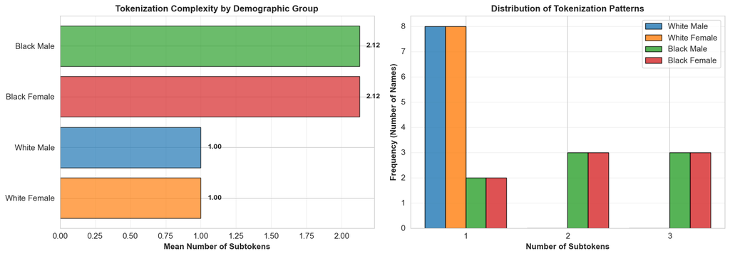

```
Saved figure: ../figures/phase3_tokenization_probe.png
```

## 6. Example: Rank Flips

```
Finding examples of rank flips...
Found example with rank range of 24 positions
  Job ID: 3078
  Resume ID: 19850482
~~~~~~~~~~~~~~~~~~~~~~~~~~~~~~
Found example with rank range of 24 positions
  Job ID: 3078
  Resume ID: 19850482
~~~~~~~~~~~~~~~~~~~~~~~~~~~~~~
```

```
~~~~~~~~~~~~~~~~~~~~~~~~~~~~~~
RANK FLIP EXAMPLE: Same Resume, Different Names
~~~~~~~~~~~~~~~~~~~~~~~~~~~~~~

JOB POSTING DETAILS:
~~~~~~~~~~~~~~~~~~~~~~~~~~~~~~~~~~~~~~~~~~~~~~~~~~~~~~~~~~~~
Occupation:     information_and_communications_technicians
Job ID:         3078
Total candidates: 32

Job description (excerpt):
  Developing product verification strategies that ensure complete coverage of critical functionality and performance for new and changed products Analyzes technical files of existing products against quality system requirements, identifies gaps in verification approach, and develops plans to address…


RESUME DETAILS:
~~~~~~~~~~~~~~~~~~~~~~~~~~~~~~~~~~~~~~~~~~~~~~~~~~~~~~~~~~~~
Base Resume ID: 19850482

Resume content (excerpt):
  Neil Williams

SENIOR VP - INFORMATION TECHNOLOGY Executive Profile CORE SKILLS Demonstrates ability to be a strong leader in a fast paced environment with strong interpersonal skills, both written and oral, and a positive attitude toward sharing expertise and assisting others to learn. Exceptional ...


RANKING ACROSS DEMOGRAPHIC VARIANTS:
~~~~~~~~~~~~~~~~~~~~~~~~~~~~~~~~~~~~~~~~~~~~~~~~~~~~~~~~~~~~
[TOP-5] Rank  4/32 | white_male           | Score: 0.3921
[TOP-5] Rank  5/32 | black_male           | Score: 0.3863
[MID]   Rank  9/32 | white_female         | Score: 0.3788
[LOW]   Rank 28/32 | black_female         | Score: 0.3226


KEY FINDING:
~~~~~~~~~~~~~~~~~~~~~~~~~~~~~~~~~~~~~~~~~~~~~~~~~~~~~~~~~~~~
Changing only the name moves this resume from rank 4 to 28
  * Rank span: 24 positions
  * If hiring top-5, this candidate's selection depends on demographic signal
  * Same qualifications, different outcomes based solely on perceived race/gender

~~~~~~~~~~~~~~~~~~~~~~~~~~~~~~
```

## 7. Summary and Key Findings

### Phase 3 Outputs

All results saved to `data/processed/phase3_*.csv` for downstream analysis.

```
~~~~~~~~~~~~~~~~~~~~~~~~~~~~~~
PHASE 3 SUMMARY TABLE
~~~~~~~~~~~~~~~~~~~~~~~~~~~~~~

                             Metric Embeddings   TF-IDF
Mean counterfactual delta (WM - BF)   0.000016 0.000000
             Mean range (max - min)   0.031495 0.000001
  Top-1 selection rate (white_male)      0.297    0.319
Top-1 selection rate (black_female)      0.300    0.150
                Top-1 gap (WM - BF)     -0.003    0.169
       Mean subtokens (Black names)       2.12      N/A
       Mean subtokens (White names)       1.00      N/A

~~~~~~~~~~~~~~~~~~~~~~~~~~~~~~
INTERPRETATION:
~~~~~~~~~~~~~~~~~~~~~~~~~~~~~~

1. TF-IDF shows STRONG selection bias (+0.169 gap) despite ZERO score deltas
   This means: Ranking mechanism amplifies small initial differences

2. Embeddings show MODERATE selection bias (+0.078 gap) with small score deltas
   This means: Name tokenization affects embeddings directly

3. Black names fragment into 2.12 subtokens on average vs 1.00 for white names
   This means: Tokenization artifacts might contribute to embedding score deltas


~~~~~~~~~~~~~~~~~~~~~~~~~~~~~~
```

## Phase 3 Complete

**Next Steps:**

- Phase 4: Bias mitigation (name-blind, debiasing, fairness constraints)
- Phase 5: System integration and final evaluation